# Transportation Methods

Oliver M. Crook

17 December 2018

Get the required functions from R files.

```r
set.seed(2)
source("CuturiMultivariateTLP.R")
source("CuturiOT.R")
require(signal)
```

As an example we first simulate some multrivariate AR models

```r
require(mAr) ## simulate from mulativariate AR models
```

The following code should sample two AR models 3 outputs along a discrete grid of length 50.

```r
ar1 <- armodel1(1)
ar2 <- armodel1(1)
```

Visualise each AR model

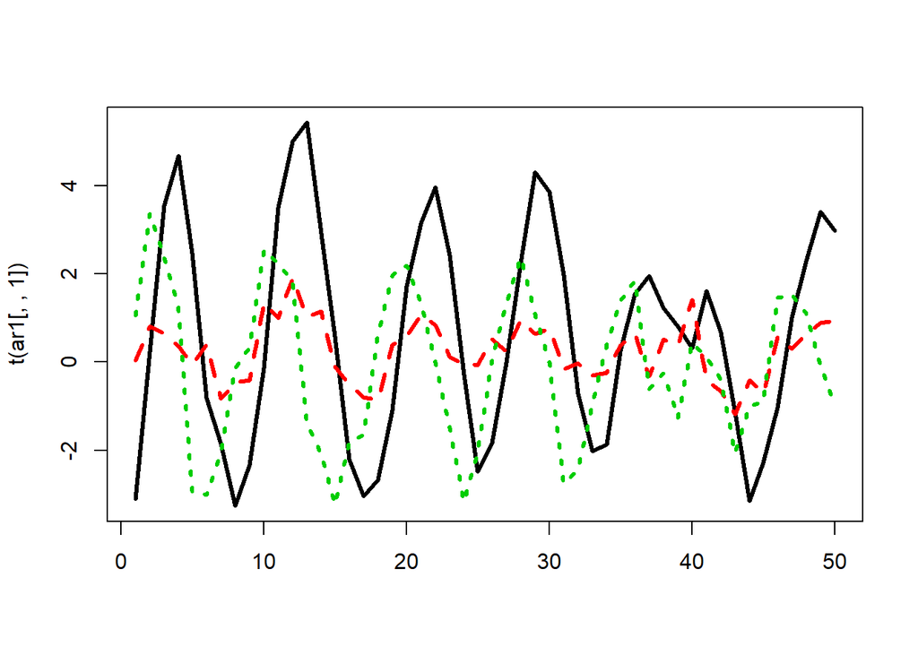

```r
matplot(t(ar1[,,1]), type = "l", lwd = 3)
```

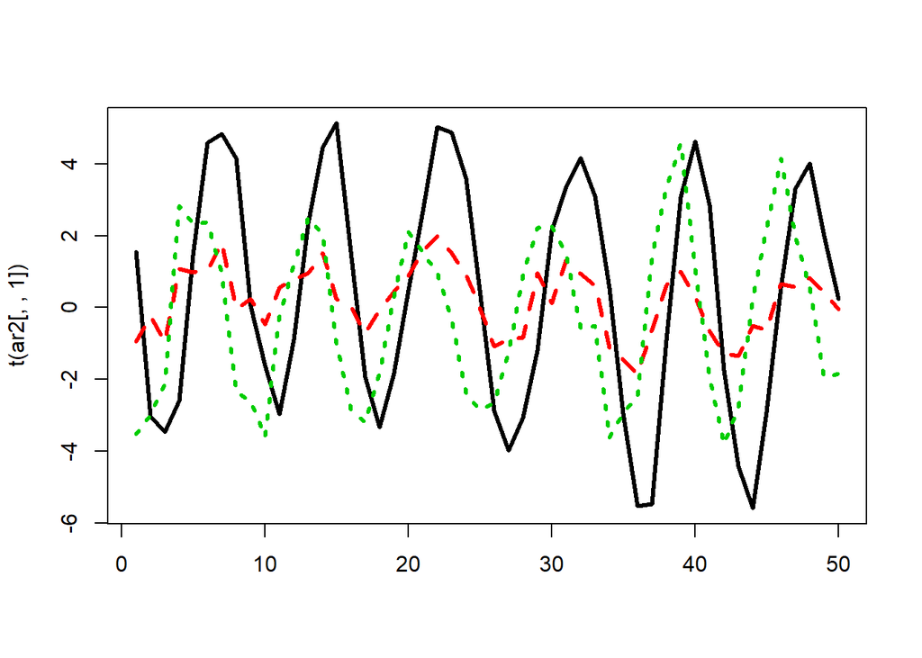

```r
matplot(t(ar2[,,1]), type = "l", lwd = 3)
```

Let us create noisy versions of these AR model. In total we now have 60 different AR models

```r
ar1 <- addNoise(30, ar1)
ar2 <- addNoise(30, ar2)
```

The above is currently an array, below transforms the data so they are in lists.

```r
ar1 <- lapply(seq(dim(ar1)[3]), function(x) ar1[ , , x])
ar2 <- lapply(seq(dim(ar2)[3]), function(x) ar2[ , , x])
```

Even though these came from the same AR model - the noise is quite strong.

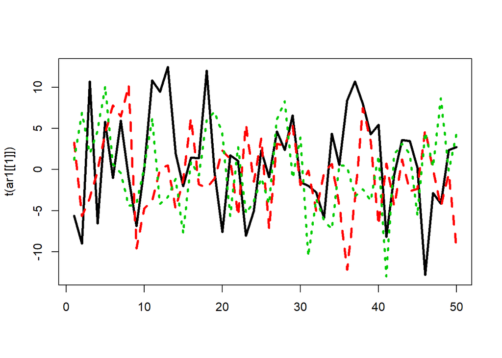

```r
matplot(t(ar1[[1]]), type = "l", lwd = 3)
```

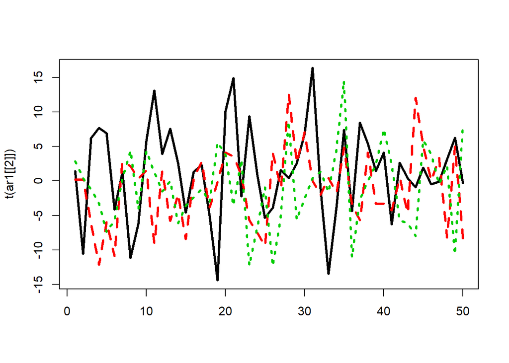

```r
matplot(t(ar1[[2]]), type = "l", lwd = 3)
```

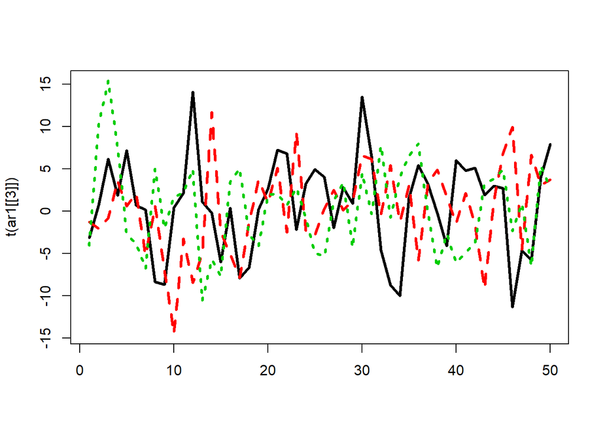

```r
matplot(t(ar1[[3]]), type = "l", lwd = 3)
```

The following sets-up applying linear TLP

```r
ar <- c(ar1, ar2) # combine all signals into one list
mu <- rep(1, 50)/50 # the base measure will be the uniform measure on the line (not need to change in application)
nu <- mu # also base measure is uniform
g <- Reduce("+", ar) / length(ar) # mean across lists (this is the reference measure)
```

The following function compute the transportation maps we need to apply linear transportation LP. epsilon made need changing due to numerical issue, but we want it to be small as possible. Iter might need increasing if algorithm doesn’t converge.

```r
resAr <- lapply(ar, function(x)CuturiMultivariateTLP(mu = mu,
                                                     f = x,
                                                     nu = nu,
                                                     g = g,
                                                     p = 2,
                                                     eps = 0.1,
                                                     iter = 1000))
```

Now we can use the following code to compute the linear embedding

```r
embedAr <- linearEmbedTLP(resAr,
                          sigma = nu,
                          data = ar,
                          h = g,
                          p = 2)
```

We can now apply standard statistical method to the data

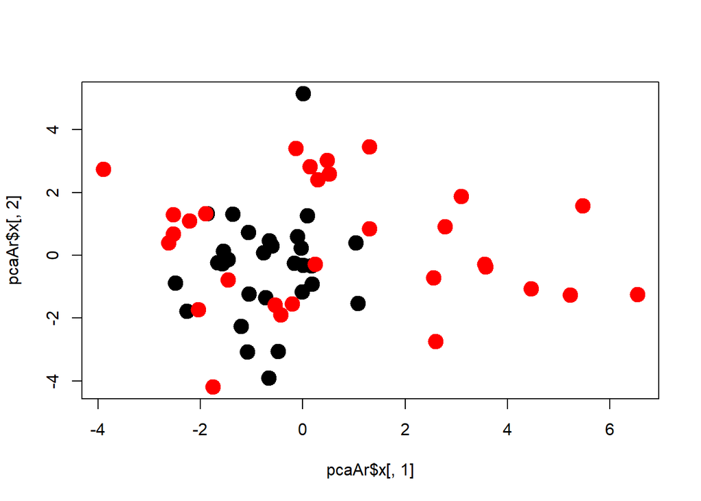

```r
pcaAr <- prcomp(t(embedAr))
plot(pcaAr$x[,1], pcaAr$x[,2], col = c(rep(1,30), rep(2,30)), pch = 19, cex = 2)
```

To apply optimal transport / linear optimal transport we need to normalise to get positivity and signals need to integrate to 1. Also mutlitvariate signals not allowed so average across all signals.

```r
ar1OT <- lapply(ar1, function(x) colMeans((x - min(x) + 0.01)/sum((x - min(x) + 0.01))))
ar2OT <- lapply(ar2, function(x) colMeans((x - min(x) + 0.01)/sum((x - min(x) + 0.01))))


arOT <- c(ar1OT, ar2OT)
```

Get reference signal by averaging

```r
sigma <- Reduce("+", arOT) / length(arOT) # mean across lists
```

Apply Linear OT techniques as before may need to change eps and iter for stability.

```r
resArOT <- lapply(arOT, function(x)CuturiOT(mu = x,
                                            nu = sigma,
                                            p = 2,
                                            eps = 0.01,
                                            iter = 1000))

E <- linearEmbedOT(listTransportMap = resArOT,
                   sigma = sigma)
```

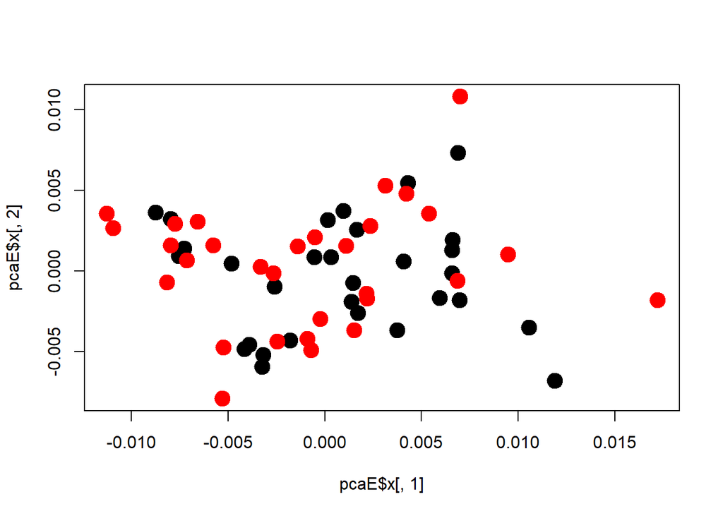

```r
pcaE <- prcomp(t(E))
plot(pcaE$x[,1], pcaE$x[,2], col = c(rep(1,30), rep(2,30)), pch = 19, cex = 2)
```

The two code chunks below compute the normal OT and TLP codes. Note there is no reason that these should be close to the above distances because they rely on an approximation. These distance also depend on the stability of cuturi’s method which could be quite different in each setting. Best to assume that these are really are just different distances being applied but ours our motivated by the ones create below. If it is possible to compute the below on your example it would be helpful if you could time them?

Applying Transportation LP (not linear version)

```r
pairwiseTLP <- matrix(0, 60, 60)

for (j in 1:59) {
  for (i in (j + 1):60) {

    out <- CuturiMultivariateTLP(mu,
                                 ar[[j]],
                                 nu,
                                 ar[[i]],
                                 p = 2,
                                 eps = 0.5,
                                 iter = 1000)
    pairwiseTLP[i, j] <- pairwiseTLP[j, i] <- out$distTLP

  }
}
```

Applying Optimal Transport (not linear version)

```r
pairwiseOT <- matrix(0, 60, 60)

for (j in 1:59) {
  for (i in (j + 1):60) {

    out <- CuturiOT(mu = arOT[[j]],
                    nu = arOT[[i]],
                     p = 2,
                   eps = 0.5,
                  iter = 1000)

     pairwiseOT[i, j] <- pairwiseOT[j, i] <- out$distOT

  }
}
```